# 1. Neighborhood Deprivation Indices

Ian D. Buller (GitHub: @idblr)

2025-08-29

Start with the necessary packages for the vignette.

```r
loadedPackages <- c('dplyr', 'ggplot2', 'ndi', 'sf', 'tidycensus', 'tigris')
invisible(lapply(loadedPackages, library, character.only = TRUE))
options(tigris_use_cache = TRUE)
```

Set your U.S. Census Bureau access key. Follow [this link](http://api.census.gov/data/key_signup.html) to obtain one. Specify your access key in the `messer()` or `powell_wiley()` functions using the `key` argument of the `get_acs()` function from the [*tidycensus*](https://CRAN.R-project.org/package=tidycensus) package called within each or by using the `census_api_key()` function from the [*tidycensus*](https://CRAN.R-project.org/package=tidycensus) package before running the `messer()` or `powell_wiley()` functions (see an example of the latter below).

```r
census_api_key('...') # INSERT YOUR OWN KEY FROM U.S. CENSUS API
```

## Compute *NDI* (Messer)

Compute the *NDI* (Messer) values (2006-2010 5-year ACS) for Georgia, U.S.A., census tracts. This metric is based on [Messer et al. (2006)](https://doi.org/10.1007/s11524-006-9094-x) with the following socio-economic status (SES) variables:

| Characteristic | SES dimension | ACS table source | Description |
| --- | --- | --- | --- |
| OCC | Occupation | C24030 | Percent males in management, science, and arts occupation |
| CWD | Housing | B25014 | Percent of crowded housing |
| POV | Poverty | B17017 | Percent of households in poverty |
| FHH | Poverty | B25115 | Percent of female headed households with dependents |
| PUB | Poverty | B19058 | Percent of households on public assistance |
| U30 | Poverty | B19001 | Percent households earning <$30,000 per year |
| EDU | Education | B06009 | Percent earning less than a high school education |
| EMP | Employment | B23001 (2010 only); B23025 (2011 onward) | Percent unemployed |

```r
messer2010GA <- messer(state = 'GA', year = 2010, round_output = TRUE)
```

One output from the `messer()` function is a tibble containing the identification, geographic name, *NDI* (Messer) values, and raw census characteristics for each tract.

```r
messer2010GA$ndi
```

```
## # A tibble: 1,969 × 14
##    GEOID state county tract     NDI NDIQuart   OCC   CWD   POV   FHH   PUB   U30
##    <chr> <chr> <chr>  <chr>   <dbl> <fct>    <dbl> <dbl> <dbl> <dbl> <dbl> <dbl>
##  1 1300… Geor… Appli… 9501  -0.0075 2-Below…     0   0     0.1   0.1   0.1   0.3
##  2 1300… Geor… Appli… 9502   0.0458 4-Most …     0   0     0.3   0.1   0.2   0.5
##  3 1300… Geor… Appli… 9503   0.0269 3-Above…     0   0     0.2   0     0.2   0.4
##  4 1300… Geor… Appli… 9504  -0.0083 2-Below…     0   0     0.1   0     0.1   0.3
##  5 1300… Geor… Appli… 9505   0.0231 3-Above…     0   0     0.2   0     0.2   0.4
##  6 1300… Geor… Atkin… 9601   0.0619 4-Most …     0   0.1   0.2   0.2   0.2   0.5
##  7 1300… Geor… Atkin… 9602   0.0593 4-Most …     0   0.1   0.3   0.1   0.2   0.4
##  8 1300… Geor… Atkin… 9603   0.0252 3-Above…     0   0     0.3   0.1   0.2   0.4
##  9 1300… Geor… Bacon… 9701   0.0061 3-Above…     0   0     0.2   0     0.2   0.4
## 10 1300… Geor… Bacon… 9702…  0.0121 3-Above…     0   0     0.2   0.1   0.1   0.5
## # ℹ 1,959 more rows
## # ℹ 2 more variables: EDU <dbl>, EMP <dbl>
```

A second output from the `messer()` function is the results from the principal component analysis used to compute the *NDI* (Messer) values.

```r
messer2010GA$pca
```

```
## Principal Components Analysis
## Call: psych::principal(r = ndi_data_pca, nfactors = 1, n.obs = nrow(ndi_data_pca),
##     covar = FALSE, scores = TRUE, missing = imp)
## Standardized loadings (pattern matrix) based upon correlation matrix
##       PC1   h2   u2 com
## OCC -0.59 0.35 0.65   1
## CWD  0.47 0.22 0.78   1
## POV  0.87 0.76 0.24   1
## FHH  0.67 0.45 0.55   1
## PUB  0.89 0.79 0.21   1
## U30  0.90 0.81 0.19   1
## EDU  0.79 0.62 0.38   1
## EMP  0.46 0.21 0.79   1
##
##                 PC1
## SS loadings    4.21
## Proportion Var 0.53
##
## Mean item complexity =  1
## Test of the hypothesis that 1 component is sufficient.
##
## The root mean square of the residuals (RMSR) is  0.11
##  with the empirical chi square  1221.09  with prob <  2.3e-246
##
## Fit based upon off diagonal values = 0.95
```

A third output from the `messer()` function is a tibble containing a breakdown of the missingness of the census characteristics used to compute the *NDI* (Messer) values.

```r
messer2010GA$missing
```

```
## # A tibble: 8 × 4
##   variable total n_missing percent_missing
##   <chr>    <int>     <int> <chr>
## 1 CWD       1969        14 0.71 %
## 2 EDU       1969        13 0.66 %
## 3 EMP       1969        13 0.66 %
## 4 FHH       1969        14 0.71 %
## 5 OCC       1969        15 0.76 %
## 6 POV       1969        14 0.71 %
## 7 PUB       1969        14 0.71 %
## 8 U30       1969        14 0.71 %
```

We can visualize the *NDI* (Messer) values geographically by linking them to spatial information from the [*tigris*](https://CRAN.R-project.org/package=tigris) package and plotting with the [*ggplot2*](https://CRAN.R-project.org/package=ggplot2) package suite.

```r
# Obtain the 2010 counties from the 'tigris' package
county2010GA <- counties(state = 'GA', year = 2010, cb = TRUE)
# Remove first 9 characters from GEOID for compatibility with tigris information
county2010GA$GEOID <- substring(county2010GA$GEO_ID, 10)

# Obtain the 2010 census tracts from the 'tigris' package
tract2010GA <- tracts(state = 'GA', year = 2010, cb = TRUE)
# Remove first 9 characters from GEOID for compatibility with tigris information
tract2010GA$GEOID <- substring(tract2010GA$GEO_ID, 10)

# Join the NDI (Messer) values to the census tract geometry
GA2010messer <- tract2010GA %>%
  left_join(messer2010GA$ndi, by = 'GEOID')
```

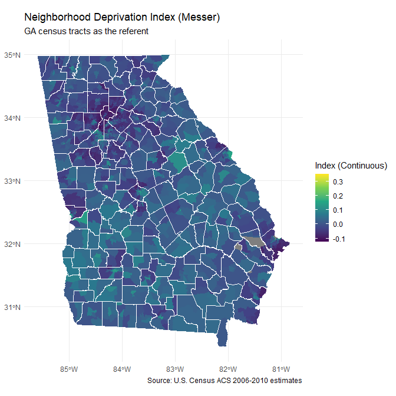

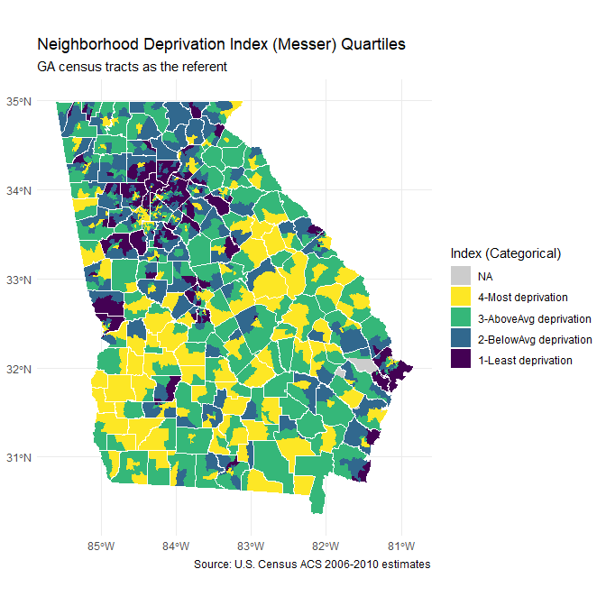

```r
# Visualize the NDI (Messer) values (2006-2010 5-year ACS) for Georgia, U.S.A., census tracts
## Continuous Index
ggplot() +
  geom_sf(
    data = GA2010messer,
    aes(fill = NDI),
    size = 0.05,
    color = 'transparent'
  ) +
  geom_sf(
    data = county2010GA,
    fill = 'transparent',
    color = 'white',
    size = 0.10
  ) +
  theme_minimal() +
  scale_fill_viridis_c() +
  labs(fill = 'Index (Continuous)', caption = 'Source: U.S. Census ACS 2006-2010 estimates') +
  ggtitle(
    'Neighborhood Deprivation Index (Messer)',
    subtitle = 'GA census tracts as the referent'
  )

## Categorical Index
### Rename '9-NDI not avail' level as NA for plotting
GA2010messer$NDIQuartNA <-
  factor(
    replace(
      as.character(GA2010messer$NDIQuart),
      GA2010messer$NDIQuart == '9-NDI not avail',
      NA
    ),
    c(levels(GA2010messer$NDIQuart)[-5], NA)
  )

ggplot() +
  geom_sf(
    data = GA2010messer,
    aes(fill = NDIQuartNA),
    size = 0.05,
    color = 'transparent'
  ) +
  geom_sf(
    data = county2010GA,
    fill = 'transparent',
    color = 'white',
    size = 0.10
  ) +
  theme_minimal() +
  scale_fill_viridis_d(guide = guide_legend(reverse = TRUE), na.value = 'grey80') +
  labs(fill = 'Index (Categorical)', caption = 'Source: U.S. Census ACS 2006-2010 estimates') +
  ggtitle(
    'Neighborhood Deprivation Index (Messer) Quartiles',
    subtitle = 'GA census tracts as the referent'
  )
```

The results above are at the tract level. The *NDI* (Messer) values can also be calculated at the county level.

```r
messer2010GA_county <- messer(geo = 'county', state = 'GA', year = 2010)

# Join the NDI (Messer) values to the county geometry
GA2010messer_county <- county2010GA %>%
  left_join(messer2010GA_county$ndi, by = 'GEOID')
```

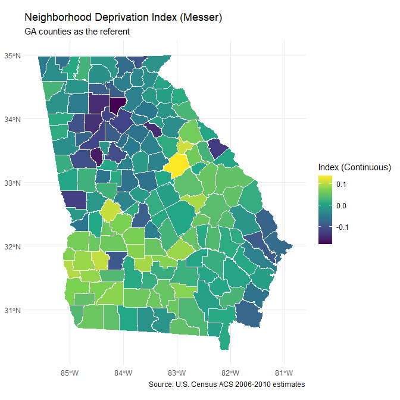

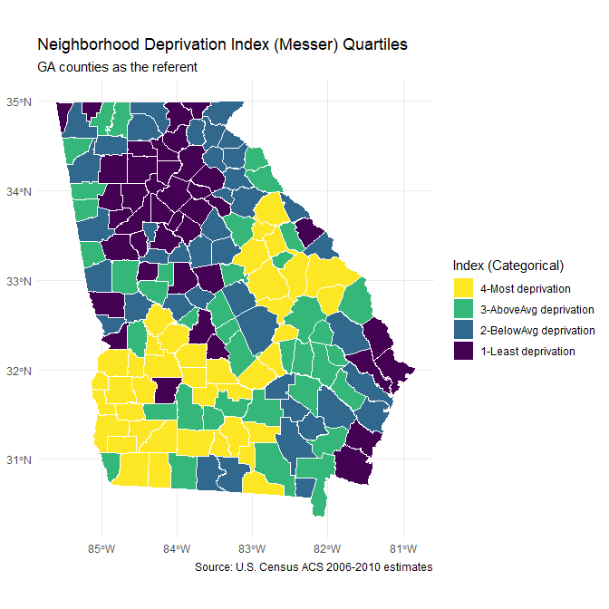

```r
# Visualize the NDI (Messer) values (2006-2010 5-year ACS) for Georgia, U.S.A., counties
## Continuous Index
ggplot() +
  geom_sf(
    data = GA2010messer_county,
    aes(fill = NDI),
    size = 0.10,
    color = 'white'
  ) +
  theme_minimal() +
  scale_fill_viridis_c() +
  labs(fill = 'Index (Continuous)', caption = 'Source: U.S. Census ACS 2006-2010 estimates') +
  ggtitle(
    'Neighborhood Deprivation Index (Messer)',
    subtitle = 'GA counties as the referent'
  )

## Categorical Index
### Rename '9-NDI not avail' level as NA for plotting
GA2010messer_county$NDIQuartNA <-
  factor(
    replace(
      as.character(GA2010messer_county$NDIQuart),
      GA2010messer_county$NDIQuart == '9-NDI not avail',
      NA
    ),
    c(levels(GA2010messer_county$NDIQuart)[-5], NA)
  )

ggplot() +
  geom_sf(
    data = GA2010messer_county,
    aes(fill = NDIQuartNA),
    size = 0.10,
    color = 'white'
  ) +
  theme_minimal() +
  scale_fill_viridis_d(guide = guide_legend(reverse = TRUE), na.value = 'grey80') +
  labs(fill = 'Index (Categorical)', caption = 'Source: U.S. Census ACS 2006-2010 estimates') +
  ggtitle(
    'Neighborhood Deprivation Index (Messer) Quartiles',
    subtitle = 'GA counties as the referent'
  )
```

## Compute *NDI* (Powell-Wiley)

Compute the *NDI* (Powell-Wiley) values (2016-2020 5-year ACS) for Maryland, Virginia, Washington, D.C., and West Virginia, U.S.A., census tracts. This metric is based on [Andrews et al. (2020)](https://doi.org/10.1080/17445647.2020.1750066) and [Slotman et al. (2022)](https://doi.org/10.1016/j.dib.2022.108002) with socio-economic status (SES) variables chosen by [Roux and Mair (2010)](https://doi.org/10.1111/j.1749-6632.2009.05333.x):

| Characteristic | SES dimension | ACS table source | Description |
| --- | --- | --- | --- |
| MedHHInc | Wealth and income | B19013 | Median household income (dollars) |
| PctRecvIDR | Wealth and income | B19054 | Percent of households receiving dividends, interest, or rental income |
| PctPubAsst | Wealth and income | B19058 | Percent of households receiving public assistance |
| MedHomeVal | Wealth and income | B25077 | Median home value (dollars) |
| PctMgmtBusSciArt | Occupation | C24060 | Percent in a management, business, science, or arts occupation |
| PctFemHeadKids | Occupation | B11005 | Percent of households that are female headed with any children under 18 years |
| PctOwnerOcc | Housing conditions | DP04 | Percent of housing units that are owner occupied |
| PctNoPhone | Housing conditions | DP04 | Percent of households without a telephone |
| PctNComPlmb | Housing conditions | DP04 | Percent of households without complete plumbing facilities |
| PctEducHSPlus | Education | S1501 | Percent with a high school degree or higher (population 25 years and over) |
| PctEducBchPlus | Education | S1501 | Percent with a college degree or higher (population 25 years and over) |
| PctFamBelowPov | Wealth and income | S1702 | Percent of families with incomes below the poverty level |
| PctUnempl | Occupation | S2301 | Percent unemployed |

More information about the [codebook](https://gis.cancer.gov/research/NeighDeprvIndex_Methods.pdf) and [computation](https://gis.cancer.gov/research/NeighDeprvIndex_Methods.pdf) of the *NDI* (Powell-Wiley) can be found on a [GIS Portal for Cancer Research](https://gis.cancer.gov/research/files.html#soc-dep) website.

```r
powell_wiley2020DMVW <- powell_wiley(
  state = c('DC', 'MD', 'VA', 'WV'),
  year = 2020,
  round_output = TRUE
)
```

One output from the `powell_wiley()` function is a tibble containing the identification, geographic name, *NDI* (Powell-Wiley) values, and raw census characteristics for each tract.

```r
powell_wiley2020DMVW$ndi
```

```
## # A tibble: 4,425 × 20
##    GEOID       state  county tract   NDI NDIQuint MedHHInc PctRecvIDR PctPubAsst
##    <chr>       <chr>  <chr>  <chr> <dbl> <fct>       <dbl>      <dbl>      <dbl>
##  1 11001000101 Distr… Distr… 1.01  -2.13 1-Least…   187839       50.9        0.8
##  2 11001000102 Distr… Distr… 1.02  -2.46 1-Least…   184167       52.2        0.6
##  3 11001000201 Distr… Distr… 2.01  NA    9-NDI n…       NA      NaN        NaN
##  4 11001000202 Distr… Distr… 2.02  -2.30 1-Least…   164261       49.6        0.9
##  5 11001000300 Distr… Distr… 3     -2.06 1-Least…   156483       46          0.6
##  6 11001000400 Distr… Distr… 4     -2.09 1-Least…   153397       47.8        0
##  7 11001000501 Distr… Distr… 5.01  -2.11 1-Least…   119911       44.5        0.8
##  8 11001000502 Distr… Distr… 5.02  -2.21 1-Least…   153264       46.8        0.5
##  9 11001000600 Distr… Distr… 6     -2.16 1-Least…   154266       60.8        7.4
## 10 11001000702 Distr… Distr… 7.02  -1.20 1-Least…    71747       22.9        0
## # ℹ 4,415 more rows
## # ℹ 11 more variables: MedHomeVal <dbl>, PctMgmtBusScArti <dbl>,
## #   PctFemHeadKids <dbl>, PctOwnerOcc <dbl>, PctNoPhone <dbl>,
## #   PctNComPlmb <dbl>, PctEducHSPlus <dbl>, PctEducBchPlus <dbl>,
## #   PctFamBelowPov <dbl>, PctUnempl <dbl>, TotalPop <dbl>
```

A second output from the `powell_wiley()` function is the results from the principal component analysis used to compute the *NDI* (Powell-Wiley) values.

```r
powell_wiley2020DMVW$pca
```

```
## $loadings
##
## Loadings:
##                 PC1    PC2    PC3
## logMedHHInc     -0.638 -0.364
## PctNoIDRZ        0.612  0.319
## PctPubAsstZ      0.379  0.615
## logMedHomeVal   -0.893
## PctWorkClassZ    0.974
## PctFemHeadKidsZ  0.128  0.697 -0.233
## PctNotOwnerOccZ -0.375  0.923
## PctNoPhoneZ             0.329  0.524
## PctNComPlmbZ           -0.141  0.869
## PctEducLTHSZ     0.642  0.164
## PctEducLTBchZ    1.020 -0.121
## PctFamBelowPovZ  0.219  0.698
## PctUnemplZ              0.596
##
##                  PC1   PC2   PC3
## SS loadings    4.340 2.971 1.102
## Proportion Var 0.334 0.229 0.085
## Cumulative Var 0.334 0.562 0.647
##
## $rotmat
##             [,1]       [,2]       [,3]
## [1,]  0.68516447  0.4403017 0.04517229
## [2,] -0.95446519  1.0806634 0.03196818
## [3,] -0.09078904 -0.2028145 1.02053725
##
## $rotation
## [1] "promax"
##
## $Phi
##           [,1]      [,2]      [,3]
## [1,] 1.0000000 0.5250277 0.1649550
## [2,] 0.5250277 1.0000000 0.1923867
## [3,] 0.1649550 0.1923867 1.0000000
##
## $Structure
##             [,1]        [,2]        [,3]
```

[output cut: 18 more lines]

```
## $uniqueness
##     logMedHHInc       PctNoIDRZ     PctPubAsstZ   logMedHomeVal   PctWorkClassZ
##     0.453113047     0.522518997     0.477946655     0.198725386     0.042320711
## PctFemHeadKidsZ PctNotOwnerOccZ     PctNoPhoneZ    PctNComPlmbZ    PctEducLTHSZ
##     0.443306153     0.003150984     0.617045044     0.222579117     0.560148142
##   PctEducLTBchZ PctFamBelowPovZ      PctUnemplZ
##    -0.056047809     0.464042693     0.638347726
##
## $Vaccounted
##                            [,1]      [,2]       [,3]
## SS loadings           4.5987837 3.2131788 1.10386926
## Proportion Var        0.3537526 0.2471676 0.08491302
## Cumulative Var        0.3537526 0.6009202 0.68583321
## Proportion Explained  0.5157997 0.3603902 0.12381002
## Cumulative Proportion 0.5157997 0.8761900 1.00000000
```

A third output from the `powell_wiley()` function is a tibble containing a breakdown of the missingness of the census characteristics used to compute the *NDI* (Powell-Wiley) values.

```r
powell_wiley2020DMVW$missing
```

```
## # A tibble: 13 × 4
##    variable        total n_missing percent_missing
##    <chr>           <int>     <int> <chr>
##  1 PctEducLTBchZ    4425        47 1.06 %
##  2 PctEducLTHSZ     4425        47 1.06 %
##  3 PctFamBelowPovZ  4425        63 1.42 %
##  4 PctFemHeadKidsZ  4425        60 1.36 %
##  5 PctNComPlmbZ     4425        60 1.36 %
##  6 PctNoIDRZ        4425        60 1.36 %
##  7 PctNoPhoneZ      4425        60 1.36 %
##  8 PctNotOwnerOccZ  4425        60 1.36 %
##  9 PctPubAsstZ      4425        60 1.36 %
## 10 PctUnemplZ       4425        57 1.29 %
## 11 PctWorkClassZ    4425        57 1.29 %
## 12 logMedHHInc      4425        73 1.65 %
## 13 logMedHomeVal    4425       148 3.34 %
```

A fourth output from the `powell_wiley()` function is a character string or numeric value of a standardized Cronbach’s alpha. A value greater than 0.7 is desired.

```r
powell_wiley2020DMVW$cronbach
```

```
## [1] 0.9321693
```

We can visualize the *NDI* (Powell-Wiley) values geographically by linking them to spatial information from the [*tigris*](https://CRAN.R-project.org/package=tigris) package and plotting with the [*ggplot2*](https://CRAN.R-project.org/package=ggplot2) package suite.

```r
# Obtain the 2020 counties from the 'tigris' package
county2020 <- counties(cb = TRUE)
county2020DMVW <- county2020[county2020$STUSPS %in% c('DC', 'MD', 'VA', 'WV'), ]

# Obtain the 2020 census tracts from the 'tigris' package
tract2020D <- tracts(state = 'DC', year = 2020, cb = TRUE)
tract2020M <- tracts(state = 'MD', year = 2020, cb = TRUE)
tract2020V <- tracts(state = 'VA', year = 2020, cb = TRUE)
tract2020W <- tracts(state = 'WV', year = 2020, cb = TRUE)
tracts2020DMVW <- rbind(tract2020D, tract2020M, tract2020V, tract2020W)

# Join the NDI (Powell-Wiley) values to the census tract geometry
DMVW2020pw <- tracts2020DMVW %>%
  left_join(powell_wiley2020DMVW$ndi, by = 'GEOID')
```

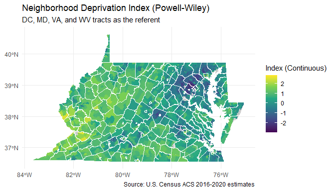

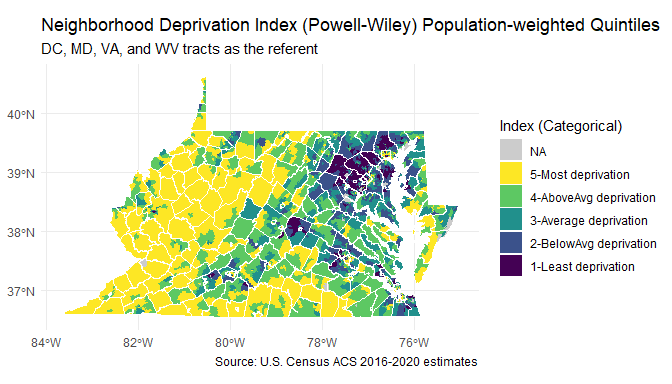

```r
# Visualize the NDI (Powell-Wiley) values (2016-2020 5-year ACS)
## Maryland, Virginia, Washington, D.C., and West Virginia, U.S.A., census tracts
## Continuous Index
ggplot() +
  geom_sf(
    data = DMVW2020pw,
    aes(fill = NDI),
    color = NA
  ) +
  geom_sf(
    data = county2020DMVW,
    fill = 'transparent',
    color = 'white'
  ) +
  theme_minimal() +
  scale_fill_viridis_c(na.value = 'grey80') +
  labs(fill = 'Index (Continuous)', caption = 'Source: U.S. Census ACS 2016-2020 estimates') +
  ggtitle(
    'Neighborhood Deprivation Index (Powell-Wiley)',
    subtitle = 'DC, MD, VA, and WV tracts as the referent'
  )

## Categorical Index (Population-weighted quintiles)
### Rename '9-NDI not avail' level as NA for plotting
DMVW2020pw$NDIQuintNA <-
  factor(replace(
    as.character(DMVW2020pw$NDIQuint),
    DMVW2020pw$NDIQuint == '9-NDI not avail',
    NA
  ),
  c(levels(DMVW2020pw$NDIQuint)[-6], NA))

ggplot() +
  geom_sf(data = DMVW2020pw, aes(fill = NDIQuintNA), color = NA) +
  geom_sf(data = county2020DMVW, fill = 'transparent', color = 'white') +
  theme_minimal() +
  scale_fill_viridis_d(guide = guide_legend(reverse = TRUE), na.value = 'grey80') +
  labs(fill = 'Index (Categorical)', caption = 'Source: U.S. Census ACS 2016-2020 estimates') +
  ggtitle(
    'Neighborhood Deprivation Index (Powell-Wiley) Population-weighted Quintiles',
    subtitle = 'DC, MD, VA, and WV tracts as the referent'
  )
```

Like the *NDI* (Messer), we also compute county-level *NDI* (Powell-Wiley).

```r
# Obtain the 2020 counties from the 'tigris' package
county2020DMVW <- counties(state = c('DC', 'MD', 'VA', 'WV'), year = 2020, cb = TRUE)

# NDI (Powell-Wiley) at the county level (2016-2020)
powell_wiley2020DMVW_county <- powell_wiley(
  geo = 'county',
  state = c('DC', 'MD', 'VA', 'WV'),
  year = 2020
)

# Join the NDI (Powell-Wiley) values to the county geometry
DMVW2020pw_county <- county2020DMVW %>%
  left_join(powell_wiley2020DMVW_county$ndi, by = 'GEOID')
```

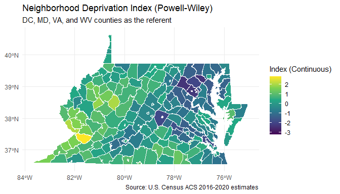

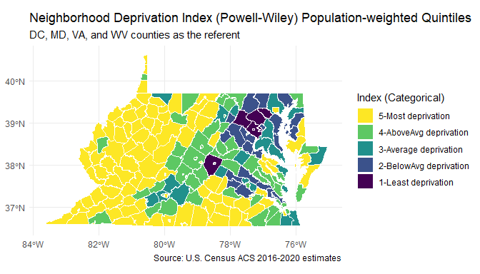

```r
# Visualize the NDI (Powell-Wiley) values (2016-2020 5-year ACS)
## Maryland, Virginia, Washington, D.C., and West Virginia, U.S.A., counties
## Continuous Index
ggplot() +
  geom_sf(
    data = DMVW2020pw_county,
    aes(fill = NDI),
    size = 0.10,
    color = 'white'
  ) +
  theme_minimal() +
  scale_fill_viridis_c() +
  labs(fill = 'Index (Continuous)', caption = 'Source: U.S. Census ACS 2016-2020 estimates') +
  ggtitle(
    'Neighborhood Deprivation Index (Powell-Wiley)',
    subtitle = 'DC, MD, VA, and WV counties as the referent'
  )

## Categorical Index
### Rename '9-NDI not avail' level as NA for plotting
DMVW2020pw_county$NDIQuintNA <-
  factor(
    replace(
      as.character(DMVW2020pw_county$NDIQuint),
      DMVW2020pw_county$NDIQuint == '9-NDI not avail',
      NA
    ),
    c(levels(DMVW2020pw_county$NDIQuint)[-6], NA)
  )

ggplot() +
  geom_sf(
    data = DMVW2020pw_county,
    aes(fill = NDIQuint),
    size = 0.10,
    color = 'white'
  ) +
  theme_minimal() +
  scale_fill_viridis_d(guide = guide_legend(reverse = TRUE), na.value = 'grey80') +
  labs(fill = 'Index (Categorical)', caption = 'Source: U.S. Census ACS 2016-2020 estimates') +
  ggtitle(
    'Neighborhood Deprivation Index (Powell-Wiley) Population-weighted Quintiles',
    subtitle = 'DC, MD, VA, and WV counties as the referent'
  )
```

### Advanced Features

#### Imputing missing census variables

```r
powell_wiley2020DC <- powell_wiley(state = 'DC', year = 2020) # without imputation
powell_wiley2020DCi <- powell_wiley(state = 'DC', year = 2020, imp = TRUE) # with imputation

table(is.na(powell_wiley2020DC$ndi$NDI)) # n=13 tracts without NDI (Powell-Wiley) values
table(is.na(powell_wiley2020DCi$ndi$NDI)) # n=0 tracts without NDI (Powell-Wiley) values

# Obtain the 2020 census tracts from the 'tigris' package
tract2020DC <- tracts(state = 'DC', year = 2020, cb = TRUE)

# Join the NDI (Powell-Wiley) values to the census tract geometry
DC2020pw <- tract2020DC %>%
  left_join(powell_wiley2020DC$ndi, by = 'GEOID')
DC2020pw <- DC2020pw %>%
  left_join(powell_wiley2020DCi$ndi, by = 'GEOID', suffix = c('_nonimp', '_imp'))
```

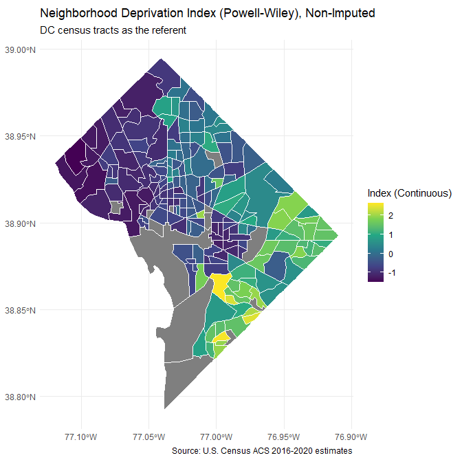

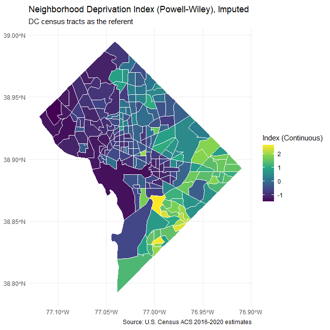

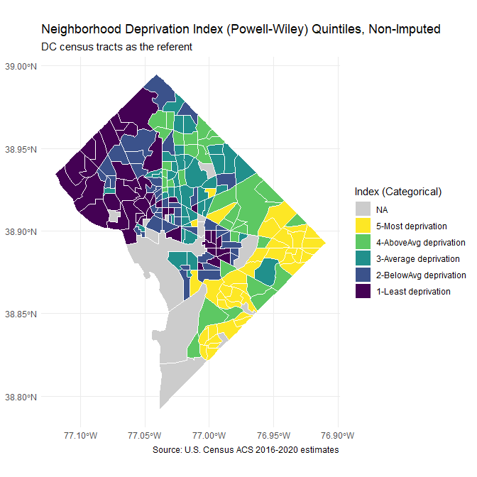

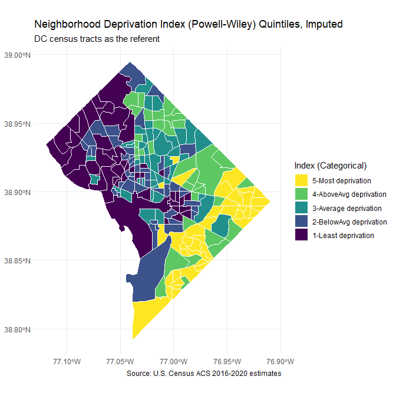

```r
# Visualize the NDI (Powell-Wiley) values (2016-2020 5-year ACS) for
## Washington, D.C., census tracts
## Continuous Index
ggplot() +
  geom_sf(
    data = DC2020pw,
    aes(fill = NDI_nonimp),
    size = 0.10,
    color = 'white'
  ) +
  theme_minimal() +
  scale_fill_viridis_c() +
  labs(fill = 'Index (Continuous)', caption = 'Source: U.S. Census ACS 2016-2020 estimates') +
  ggtitle(
    'Neighborhood Deprivation Index (Powell-Wiley), Non-Imputed',
    subtitle = 'DC census tracts as the referent'
  )

ggplot() +
  geom_sf(
    data = DC2020pw,
    aes(fill = NDI_imp),
    size = 0.10,
    color = 'white'
  ) +
  theme_minimal() +
  scale_fill_viridis_c() +
  labs(fill = 'Index (Continuous)', caption = 'Source: U.S. Census ACS 2016-2020 estimates') +
  ggtitle(
    'Neighborhood Deprivation Index (Powell-Wiley), Imputed',
    subtitle = 'DC census tracts as the referent'
  )

## Categorical Index
### Rename '9-NDI not avail' level as NA for plotting
DC2020pw$NDIQuintNA_nonimp <-
  factor(
    replace(
      as.character(DC2020pw$NDIQuint_nonimp),
      DC2020pw$NDIQuint_nonimp == '9-NDI not avail',
      NA
    ),
    c(levels(DC2020pw$NDIQuint_nonimp)[-6], NA)
  )

ggplot() +
  geom_sf(
    data = DC2020pw,
    aes(fill = NDIQuintNA_nonimp),
    size = 0.10,
    color = 'white'
  ) +
  theme_minimal() +
  scale_fill_viridis_d(guide = guide_legend(reverse = TRUE), na.value = 'grey80') +
  labs(fill = 'Index (Categorical)', caption = 'Source: U.S. Census ACS 2016-2020 estimates') +
  ggtitle(
    'Neighborhood Deprivation Index (Powell-Wiley) Quintiles, Non-Imputed',
    subtitle = 'DC census tracts as the referent'
  )

### Rename '9-NDI not avail' level as NA for plotting
DC2020pw$NDIQuintNA_imp <-
  factor(
    replace(
      as.character(DC2020pw$NDIQuint_imp),
      DC2020pw$NDIQuint_imp == '9-NDI not avail',
      NA
    ),
    c(levels(DC2020pw$NDIQuint_imp)[-6], NA)
  )

ggplot() +
  geom_sf(
    data = DC2020pw,
    aes(fill = NDIQuintNA_imp),
    size = 0.10,
    color = 'white'
  ) +
  theme_minimal() +
  scale_fill_viridis_d(guide = guide_legend(reverse = TRUE), na.value = 'grey80') +
  labs(fill = 'Index (Categorical)', caption = 'Source: U.S. Census ACS 2016-2020 estimates') +
  ggtitle(
    'Neighborhood Deprivation Index (Powell-Wiley) Quintiles, Imputed',
    subtitle = 'DC census tracts as the referent'
  )
```

#### Assign the referent (U.S.-Standardized Metric)

To conduct a contiguous US-standardized index, compute an *NDI* for all states as in the example below that replicates the nationally standardized *NDI* (Powell-Wiley) values (2013-2017 ACS-5) found in [Slotman et al. (2022)](https://doi.org/10.1016/j.dib.2022.108002) and available from a [GIS Portal for Cancer Research](https://gis.cancer.gov/research/files.html#soc-dep) website. To replicate the nationally standardized *NDI* (Powell-Wiley) values (2006-2010 ACS-5) found in [Andrews et al. (2020)](https://doi.org/10.1080/17445647.2020.1750066) change the `year` argument to `2010` (i.e., `year = 2010`).

```r
us <- states()
n51 <- c(
  'Commonwealth of the Northern Mariana Islands',
  'Guam',
  'American Samoa',
  'Puerto Rico',
  'United States Virgin Islands'
)
y51 <- us$STUSPS[!(us$NAME %in% n51)]

start_time <- Sys.time() # record start time
powell_wiley2017US <- powell_wiley(state = y51, year = 2017)
end_time <- Sys.time() # record end time
time_srr <- end_time - start_time # Calculate run time
```

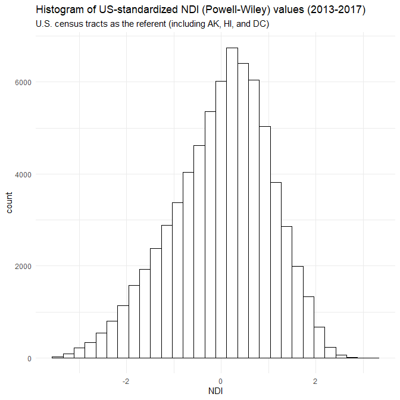

```r
ggplot(powell_wiley2017US$ndi, aes(x = NDI)) +
  geom_histogram(color = 'black', fill = 'white') +
  theme_minimal() +
  ggtitle(
    'Histogram of US-standardized NDI (Powell-Wiley) values (2013-2017)',
    subtitle = 'U.S. census tracts as the referent (including AK, HI, and DC)'
  )
```

The process to compute a US-standardized *NDI* (Powell-Wiley) took about 12.7 minutes to run on a machine with the features listed at the end of the vignette.